# BTS 510 Lab 8

```r
set.seed(12345)
library(tidyverse)
library(Stat2Data)
theme_set(theme_classic(base_size = 16))
```

## 1 Learning objectives

- **Assess** models for **(multi)collinearity** among predictors
- **Conduct** outlier analyses to determine extreme and/or problematic cases

## 2 Data

- `FirstYearGPA` data from the **Stat2Data** package: $n$ = 219 subjects
  - `GPA`: First-year college GPA on a 0.0 to 4.0 scale
  - `HSGPA`: High school GPA on a 0.0 to 4.0 scale
  - `SATV`: Verbal/critical reading SAT score
  - `SATM`: Math SAT score
  - `Male`: 1= male, 0= female
  - `HU`: Number of credit hours earned in humanities courses in high school
  - `SS`: Number of credit hours earned in social science courses in high school
  - `FirstGen`: 1= student is the first in her or his family to attend college, 0=otherwise
  - `White`: 1= white students, 0= others
  - `CollegeBound`: 1=attended a high school where >=50% students intended to go on to college, 0=otherwise

## 3 Research question(s)

- How do **all these variables** impact first year GPA (`GPA`)?
  - Are there any problems with **collinearity** among the *predictors*?
  - Are there **problematic cases** that are *influencing the results*?

## 4 Tasks

1. Run a **linear regression model** predicting `GPA` from *all other variables* in the dataset.

```r
library(Stat2Data)
data(FirstYearGPA)
FirstYearGPA <- FirstYearGPA %>%
  mutate(ID = row_number())
head(FirstYearGPA)
```

```
   GPA HSGPA SATV SATM Male   HU   SS FirstGen White CollegeBound ID
1 3.06  3.83  680  770    1  3.0  9.0        1     1            1  1
2 4.15  4.00  740  720    0  9.0  3.0        0     1            1  2
3 3.41  3.70  640  570    0 16.0 13.0        0     0            1  3
4 3.21  3.51  740  700    0 22.0  0.0        0     1            1  4
5 3.48  3.83  610  610    0 30.5  1.5        0     1            1  5
6 2.95  3.25  600  570    0 18.0  3.0        0     1            1  6
```

```r
m1 <- lm(data = FirstYearGPA, GPA ~ . - ID)
summary(m1)
```

```
Call:
lm(formula = GPA ~ . - ID, data = FirstYearGPA)

Residuals:
     Min       1Q   Median       3Q      Max
-1.07412 -0.25827  0.05384  0.27675  0.85761

Coefficients:
               Estimate Std. Error t value Pr(>|t|)
(Intercept)   0.5268983  0.3487584   1.511  0.13235
HSGPA         0.4932945  0.0745553   6.616 3.03e-10 ***
SATV          0.0005919  0.0003945   1.501  0.13498
SATM          0.0000847  0.0004447   0.190  0.84912
Male          0.0482478  0.0570277   0.846  0.39850
HU            0.0161874  0.0039723   4.075 6.53e-05 ***
SS            0.0073370  0.0055635   1.319  0.18869
FirstGen     -0.0743417  0.0887490  -0.838  0.40318
White         0.1962316  0.0700182   2.803  0.00555 **
CollegeBound  0.0214530  0.1003350   0.214  0.83090
---
Signif. codes:  0 '***' 0.001 '**' 0.01 '*' 0.05 '.' 0.1 ' ' 1

Residual standard error: 0.3834 on 209 degrees of freedom
Multiple R-squared:  0.3496,    Adjusted R-squared:  0.3216
F-statistic: 12.48 on 9 and 209 DF,  p-value: 8.674e-16
```

2. Some of those variables seem like they could be **strongly related**, which could cause problems for the model. Check to see if **collinearity** is an issue for this model. To check this, look at:
- **Correlations among variables**
- **Variable inflation factors (VIFs)**

```r
cor(FirstYearGPA)
```

```
                     GPA       HSGPA        SATV         SATM        Male
GPA           1.00000000  0.44688735  0.30431137  0.194343851  0.05284917
HSGPA         0.44688735  1.00000000  0.21032124  0.152839634 -0.09031714
SATV          0.30431137  0.21032124  1.00000000  0.526943819  0.14555703
SATM          0.19434385  0.15283963  0.52694382  1.000000000  0.37099167
Male          0.05284917 -0.09031714  0.14555703  0.370991668  1.00000000
HU            0.31465575  0.11603117  0.09874856 -0.009601549 -0.01884386
SS           -0.00356909 -0.01725443 -0.02646987 -0.087839974  0.03507603
FirstGen     -0.15657732  0.06418575 -0.25657713 -0.177387395 -0.07610526
White         0.28177214  0.04604668  0.36823365  0.259465227  0.07696022
CollegeBound -0.06302497 -0.20003903  0.06484473  0.039322063  0.09981773
ID           -0.18693938 -0.24169420 -0.09436226 -0.047312698  0.10121274
                       HU          SS     FirstGen       White CollegeBound
GPA           0.314655754 -0.00356909 -0.156577322  0.28177214  -0.06302497
HSGPA         0.116031169 -0.01725443  0.064185751  0.04604668  -0.20003903
SATV          0.098748556 -0.02646987 -0.256577125  0.36823365   0.06484473
SATM         -0.009601549 -0.08783997 -0.177387395  0.25946523   0.03932206
Male         -0.018843863  0.03507603 -0.076105261  0.07696022   0.09981773
HU            1.000000000 -0.30660787 -0.212565615  0.12593391  -0.02997230
SS           -0.306607866  1.00000000 -0.023663260  0.01673417  -0.03170649
FirstGen     -0.212565615 -0.02366326  1.000000000 -0.23790392  -0.11051100
White         0.125933908  0.01673417 -0.237903920  1.00000000  -0.02391156
CollegeBound -0.029972303 -0.03170649 -0.110511005 -0.02391156   1.00000000
ID           -0.091577232 -0.12965617  0.002725596 -0.01524922  -0.01025733
                       ID
GPA          -0.186939380
HSGPA        -0.241694202
SATV         -0.094362258
SATM         -0.047312698
Male          0.101212743
HU           -0.091577232
SS           -0.129656169
FirstGen      0.002725596
White        -0.015249216
CollegeBound -0.010257334
ID            1.000000000
```

```r
library(car)
vif(m1)
```

```
       HSGPA         SATV         SATM         Male           HU           SS
    1.158078     1.605182     1.660002     1.205737     1.221530     1.147867
    FirstGen        White CollegeBound
    1.186760     1.212049     1.073989
```

3. Based on the **correlations between each predictor and the outcome** (above), are there predictors that you think **should** be significant but aren’t? Why do you think they aren’t? (This is a bit of a philosophical question.)
4. Are there **extreme cases** that we might be concerned about? Check for extreme values in terms of:
- **Predictors**
- **Predicted values**
- **Changes to predicted values**

```r
library(broom)
m1_aug <- augment(m1)
m1_aug
```

```
# A tibble: 219 × 17
     GPA HSGPA  SATV  SATM  Male    HU    SS FirstGen White CollegeBound    ID
   <dbl> <dbl> <int> <int> <int> <dbl> <dbl>    <int> <int>        <int> <int>
 1  3.06  3.83   680   770     1   3     9          1     1            1     1
 2  4.15  4      740   720     0   9     3          0     1            1     2
 3  3.41  3.7    640   570     0  16    13          0     0            1     3
 4  3.21  3.51   740   700     0  22     0          0     1            1     4
 5  3.48  3.83   610   610     0  30.5   1.5        0     1            1     5
 6  2.95  3.25   600   570     0  18     3          0     1            1     6
 7  3.6   3.79   710   630     0   5    19          0     1            1     7
 8  2.87  3.6    390   570     0  10     0          0     0            0     8
 9  3.67  3.36   630   560     0   8.5  15.5        0     1            1     9
10  3.49  3.7    680   670     0  16    12          0     1            1    10
# ℹ 209 more rows
# ℹ 6 more variables: .fitted <dbl>, .resid <dbl>, .hat <dbl>, .sigma <dbl>,
#   .cooksd <dbl>, .std.resid <dbl>
```

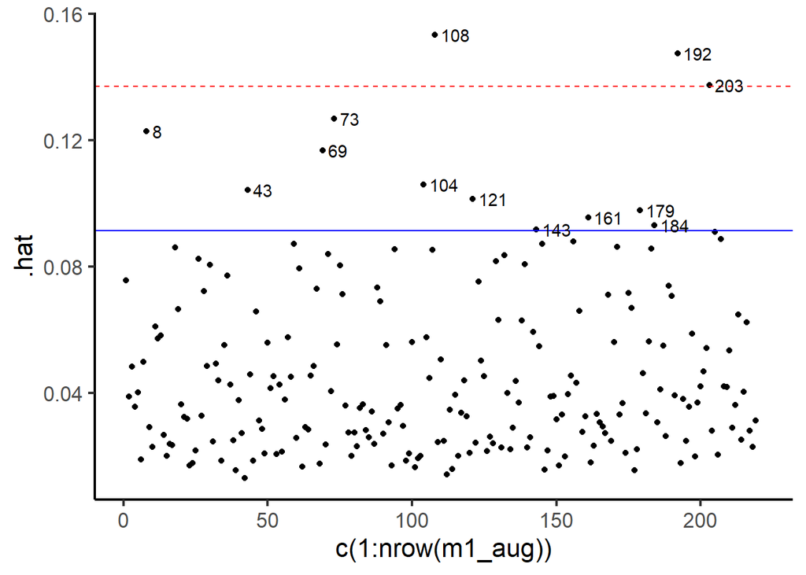

```r
ggplot(data = m1_aug,
       aes(x = c(1:nrow(m1_aug)),
           y = .hat)) +
  geom_point() +
  geom_hline(yintercept = 3*(9+1)/219,
             color = "red",
             linetype = "dashed") +
  geom_hline(yintercept = 2*(9+1)/219,
             color = "blue") +
  geom_text(aes(label=ifelse((.hat > 2*(9+1)/219),
                             as.character(ID),
                             '')),
            hjust = 0, nudge_x = 2)
```

```r
library(car)
m1_stresid <- FirstYearGPA %>% mutate(esresid = rstudent(m1))
head(m1_stresid)
```

```
   GPA HSGPA SATV SATM Male   HU   SS FirstGen White CollegeBound ID    esresid
1 3.06  3.83  680  770    1  3.0  9.0        1     1            1  1 -0.3523421
2 4.15  4.00  740  720    0  9.0  3.0        0     1            1  2  2.0524744
3 3.41  3.70  640  570    0 16.0 13.0        0     0            1  3  0.6808208
4 3.21  3.51  740  700    0 22.0  0.0        0     1            1  4 -0.3167075
5 3.48  3.83  610  610    0 30.5  1.5        0     1            1  5 -0.1895846
6 2.95  3.25  600  570    0 18.0  3.0        0     1            1  6 -0.3012032
```

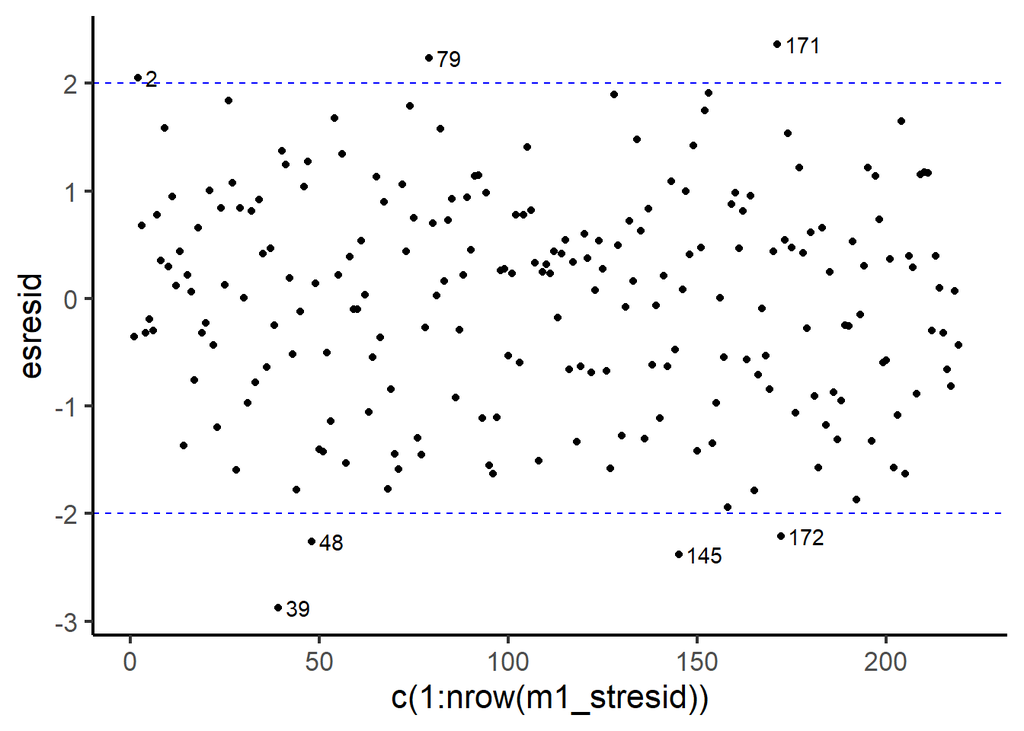

```r
ggplot(data = m1_stresid,
       aes(x = c(1:nrow(m1_stresid)),
           y = esresid)) +
  geom_point() +
  geom_hline(yintercept = 2,
             color = "blue",
             linetype = "dashed") +
  geom_hline(yintercept = -2,
             color = "blue",
             linetype = "dashed") +
  geom_text(aes(label=ifelse((esresid > 2),
                             as.character(ID),
                             '')),
            hjust = 0, nudge_x = 2) +
  geom_text(aes(label=ifelse((esresid < -2),
                             as.character(ID),
                             '')),
            hjust = 0, nudge_x = 2)
```

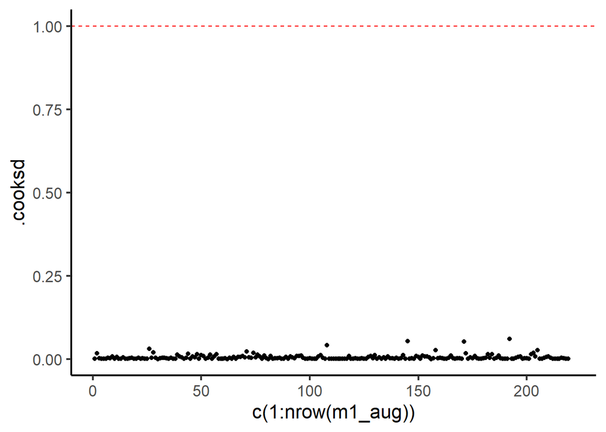

```r
ggplot(data = m1_aug,
       aes(x = c(1:nrow(m1_aug)),
           y = .cooksd)) +
  geom_point() +
  geom_hline(yintercept = 1,
             color = "red",
             linetype = "dashed") +
  geom_text(aes(label=ifelse((.cooksd > 1),
                             as.character(ID),
                             '')),
            hjust = 0, nudge_x = 2)
```

5. **Summarize** your findings about collinearity and outliers. *Use plain language.*
- Leverage

```r
m1_aug %>% filter(.hat > 2*(9+1)/219) %>% select(ID)
```

```
# A tibble: 13 × 1
      ID
   <int>
 1     8
 2    43
 3    69
 4    73
 5   104
 6   108
 7   121
 8   143
 9   161
10   179
11   184
12   192
13   203
```

- Discrepancy

```r
m1_stresid %>% filter(esresid > 2) %>% select(ID)
```

```
   ID
1   2
2  79
3 171
```

```r
m1_stresid %>% filter(esresid < -2) %>% select(ID)
```

```
   ID
1  39
2  48
3 145
4 172
```

- Influence

```r
m1_aug %>% filter(.cooksd > 1) %>% select(ID)
```

```
# A tibble: 0 × 1
# ℹ 1 variable: ID <int>
```

There were no cases with high influence as measured by Cook’s D with a cut-off of greater than 1. This indicates that no cases were changing the overall predicted values.